# Challenge: Cross Selling in Banking (CED1)

Gisler Luca, Heeb Christian, Studer Aaron, Bécheiraz Léonie

02.12.22

## Aufgabenstellung

### Allgemein

Eine tschechische Bank möchte ihre Dienstleistungen für Privatkunden verbessern und “interessante Kundengruppen” identifizieren. Die Geschäftsleitung hat keine präzise Vorstellung, möchte aber zusätzliches Business generieren ohne unnötige Risiken einzugehen und Verluste einzufahren.

Der analytische Auftrag umfasst die folgenden Aufgaben:

- Qualität und Repräsentativität der Daten zu überprüfen
- Die Verteilung der einzelnen Datenattribute zu erheben
- Deren Veränderung über die Zeit zu analysieren
- Korrelationen zwischen verschiedenen Datenattributen zu quantifizieren und zu visualisieren sowie Hypothesen hinsichtlich optimaler Produktverkauf / -nutzung zu erstellen

### Datengrundlage

Wir erhalten die Daten von einer Tschechischen Bank. Die Datengrundlage ist auf [dieser Webseite](https://sorry.vse.cz/~berka/challenge/PAST/index.html) beschrieben.

## Datenbeschreibung

Relation disposition (df_raw_disposition): disp_id: record identifier  
client_id: identification of a client  
account_id: identification of an account  
type: type of disposition (owner/user) only owner can issue permanent orders and ask for a loan

#### ERD Daten IST-Zustand

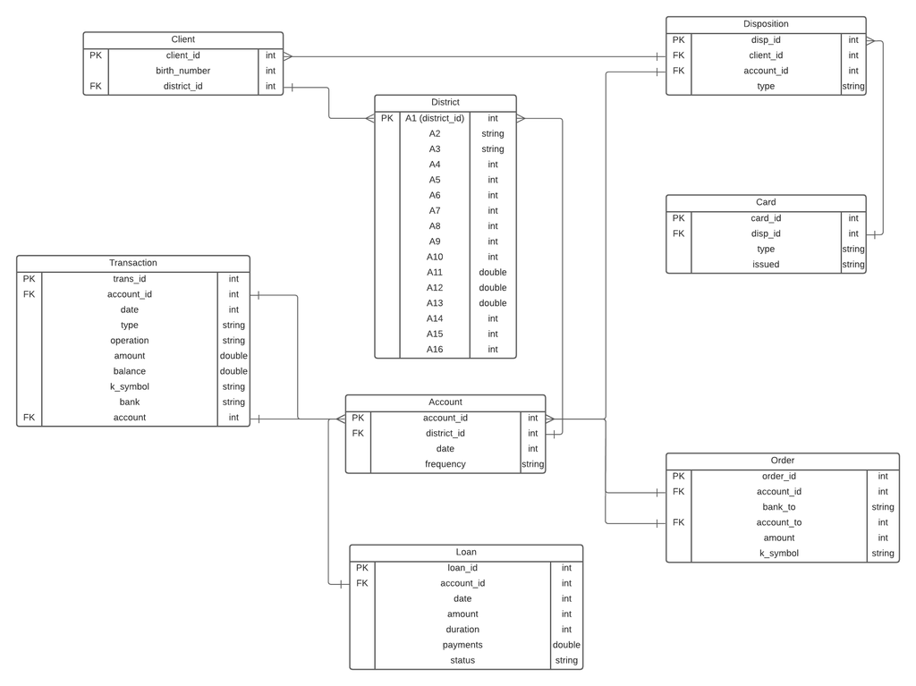

ERD Daten IST-Zustand

## Setup

```r
library(tidyverse)
library(ggmosaic)
library(ggalluvial)
library(DALEXtra)
library(visdat)
library(DT)
library(patchwork)
library(ggpubr)
library(rpart.plot)
library(tidymodels)
library(lubridate)
tidymodels_prefer()
```

### Setup Account Data Frame

In diesem Schritt wird das Data Frame Account vorbereitet und der ‘Transform’-Schritt wird durchgeführt.

```r
df_raw_account <- read.csv("../xselling_banking_data/account.csv", header = TRUE, sep = ";")

str(df_raw_account)
```

```
## 'data.frame':    4500 obs. of  4 variables:
##  $ account_id : int  576 3818 704 2378 2632 1972 1539 793 2484 1695 ...
##  $ district_id: int  55 74 55 16 24 77 1 47 74 76 ...
##  $ frequency  : chr  "POPLATEK MESICNE" "POPLATEK MESICNE" "POPLATEK MESICNE" "POPLATEK MESICNE" ...
##  $ date       : int  930101 930101 930101 930101 930102 930102 930103 930103 930103 930103 ...
```

Es wird wie folgt die Spalte ‘date’ von dem Type Integer zu dem Typ Date umgewandelt. Dabei brauchen wir die Funktionalitäten von [Lubridate](https://lubridate.tidyverse.org/). Die Spalte ‘frequency’ ist eine kategoriale Variable mit Tschechischen Werten, daher transformieren wir auch diese Werte auf Englisch.

```r
df_account <- df_raw_account %>%
  mutate(date = ymd(date)) %>%
  mutate(frequency = case_when(frequency == "POPLATEK MESICNE" ~ "Monthly",
                              frequency == "POPLATEK TYDNE" ~ "Weekly",
                              frequency == "POPLATEK PO OBRATU" ~ "After_Transaction")
  ) %>%
  arrange(account_id)
```

### Setup Client Data Frame

```r
df_raw_client <- read.csv("../xselling_banking_data/client.csv", header = TRUE, sep = ";")

str(df_raw_client)
```

```
## 'data.frame':    5369 obs. of  3 variables:
##  $ client_id   : int  1 2 3 4 5 6 7 8 9 10 ...
##  $ birth_number: int  706213 450204 406009 561201 605703 190922 290125 385221 351016 430501 ...
##  $ district_id : int  18 1 1 5 5 12 15 51 60 57 ...
```

Es wird wie folgt die Spalte ‘birth_number’ von dem Type Integer zu dem Typ Date umgewandelt, zusätzlich nennen wir die Spalte neu ‘dateofbirth’. Dabei brauchen wir die Funktionalitäten von [Lubridate](https://lubridate.tidyverse.org/). Es wird eine neue Spalte ‘sex’ hinzugefügt, mithilfe der Dokumentation der Daten kennen wir die Kondition, welches Geschlecht der Kunde hat.

```r
df_client <- df_raw_client %>%
  mutate(dateofbirth = case_when(
    strtoi(substr(as.character(birth_number), 3, 3)) > 1 ~ (ymd(birth_number - 5000)),
    TRUE ~ (ymd(birth_number)),
  )) %>%
  mutate(sex = case_when(
    strtoi(substr(as.character(birth_number), 3, 3)) > 1 ~ "Female",
    TRUE  ~ "Male"
  ))

df_client <- df_client %>%
 mutate(dateofbirth = case_when(
   year(ymd(dateofbirth)) > 2000 ~ ymd(dateofbirth) - years(100),
   TRUE ~ ymd(dateofbirth)
 )) %>%
 select(client_id, district_id, dateofbirth, sex) %>%
 arrange(client_id)
```

### Setup Disposition Data Frame

In diesem Schritt wird das Data Frame Disposition vorbereitet und der ‘Transform’-Schritt wird durchgeführt.

```r
df_raw_disposition <- read.csv("../xselling_banking_data/disp.csv", header = TRUE, sep = ";")

str(df_raw_disposition)
```

```
## 'data.frame':    5369 obs. of  4 variables:
##  $ disp_id   : int  1 2 3 4 5 6 7 8 9 10 ...
##  $ client_id : int  1 2 3 4 5 6 7 8 9 10 ...
##  $ account_id: int  1 2 2 3 3 4 5 6 7 8 ...
##  $ type      : chr  "OWNER" "OWNER" "DISPONENT" "OWNER" ...
```

In dem Date Frame disposition müssen keine weitere Schritte erledigt werden für das Transformieren der Daten.

```r
df_disposition <- df_raw_disposition %>%
 select(disp_id, client_id, account_id, type) %>%
 arrange(disp_id)
```

### Setup Order Data Frame

In diesem Schritt wird das Data Frame Order vorbereitet und der ‘Transform’-Schritt wird durchgeführt.

```r
df_raw_perm_order <- read.csv("../xselling_banking_data/order.csv", header = TRUE, sep = ";")

str(df_raw_perm_order)
```

```
## 'data.frame':    6471 obs. of  6 variables:
##  $ order_id  : int  29401 29402 29403 29404 29405 29406 29407 29408 29409 29410 ...
##  $ account_id: int  1 2 2 3 3 3 4 4 5 6 ...
##  $ bank_to   : chr  "YZ" "ST" "QR" "WX" ...
##  $ account_to: int  87144583 89597016 13943797 83084338 24485939 59972357 26693541 5848086 37390208 44486999 ...
##  $ amount    : num  2452 3373 7266 1135 327 ...
##  $ k_symbol  : chr  "SIPO" "UVER" "SIPO" "SIPO" ...
```

In dem Data Frame perm_order müssen wir die kategoriale Variable ‘k_symbol’ noch übersetzen, da der Name ‘k_symbol’ nicht ausschlaggeben ist, benennen wir die Spalte zu ‘payment_type’ um.

```r
df_perm_order <- df_raw_perm_order %>%
 mutate(payment_type = case_when(k_symbol == "POJISTNE" ~ "INSURRANCE",
                              k_symbol == "SIPO" ~ "HOUSEHOLD",
                              k_symbol == "LEASING" ~ "LEASING",
                              k_symbol == "UVER" ~ "LOAN",
                              TRUE ~ "UNKNOWN")
 ) %>%
 select(order_id, account_id, bank_to, account_to, amount, payment_type) %>%
 arrange(order_id)
```

### Setup Transaction Data Frame

In diesem Schritt wird das Data Frame Transaction vorbereitet und der ‘Transform’-Schritt wird durchgeführt.

```r
df_raw_transaction <- read.csv("../xselling_banking_data/trans.csv", header = TRUE, sep = ";")

str(df_raw_transaction)
```

```
## 'data.frame':    1056320 obs. of  10 variables:
##  $ trans_id  : int  695247 171812 207264 1117247 579373 771035 452728 725751 497211 232960 ...
##  $ account_id: int  2378 576 704 3818 1972 2632 1539 2484 1695 793 ...
##  $ date      : int  930101 930101 930101 930101 930102 930102 930103 930103 930103 930103 ...
##  $ type      : chr  "PRIJEM" "PRIJEM" "PRIJEM" "PRIJEM" ...
##  $ operation : chr  "VKLAD" "VKLAD" "VKLAD" "VKLAD" ...
##  $ amount    : num  700 900 1000 600 400 1100 600 1100 200 800 ...
##  $ balance   : num  700 900 1000 600 400 1100 600 1100 200 800 ...
##  $ k_symbol  : chr  "" "" "" "" ...
##  $ bank      : chr  "" "" "" "" ...
##  $ account   : int  NA NA NA NA NA NA NA NA NA NA ...
```

Es wird wie folgt die Spalte ‘date’ von dem Type Integer zu dem Typ Date umgewandelt. Dabei brauchen wir die Funktionalitäten von [Lubridate](https://lubridate.tidyverse.org/). Die Spalte ‘type’ muss von Tschechisch noch auf Englisch übersetzt werden. Dasselbe zählt auch für die Spalte ‘operation’ und ‘k_symbol’. Jedoch benennen wir die Splate ‘k_symbol’ noch um in die neue Spalte ‘characterization’.

```r
df_transaction <- df_raw_transaction %>%
 mutate(date = ymd(date)) %>%
 mutate(type = case_when(type == "PRIJEM" ~ "CREDIT",
                         type == "VYDAJ" ~ "WITHDRAWAL")
 ) %>%
 mutate(operation = case_when(operation == "VYBER KARTOU" ~ "CREDIT CARD WITHDRAWAL",
                              operation == "VKLAD" ~ "CASH CREDIT",
                              operation == "PREVOD Z UCTU" ~ "COLLECTION OTHER BANK",
                              operation == "VYBER" ~ "CASH WIDTHDRAWAL",
                              operation == "PREVOD NA UCET" ~ "REMITTANCE OTHER BANK")
 ) %>%
 mutate(characterization = case_when(k_symbol == "POJISTNE" ~ "INSURRANCE PAYMENT",
                              k_symbol == "SLUZBY" ~ "STATEMENT PAYMENT",
                              k_symbol == "UROK" ~ "CREDIT INTEREST",
                              k_symbol == "SANKC. UROK" ~ "SANCTION INTEREST",
                              k_symbol == "SIPO" ~ "HOUSEHOLD",
                              k_symbol == "DUCHOD" ~ "OLD AGE PENSION",
                              k_symbol == "UVER" ~ "LOAN PAYMENT")
 ) %>%
 select(trans_id, account_id, date, type, operation, amount, balance, characterization, bank, account) %>%
 arrange(trans_id)
```

### Setup Loan Data Frame

In diesem Schritt wird das Data Frame Loan vorbereitet und der ‘Transform’-Schritt wird durchgeführt.

```r
df_raw_loan <- read.csv("../xselling_banking_data/loan.csv", header = TRUE, sep = ";")

str(df_raw_loan)
```

```
## 'data.frame':    682 obs. of  7 variables:
##  $ loan_id   : int  5314 5316 6863 5325 7240 6687 7284 6111 7235 5997 ...
##  $ account_id: int  1787 1801 9188 1843 11013 8261 11265 5428 10973 4894 ...
##  $ date      : int  930705 930711 930728 930803 930906 930913 930915 930924 931013 931104 ...
##  $ amount    : int  96396 165960 127080 105804 274740 87840 52788 174744 154416 117024 ...
##  $ duration  : int  12 36 60 36 60 24 12 24 48 24 ...
##  $ payments  : num  8033 4610 2118 2939 4579 ...
##  $ status    : chr  "B" "A" "A" "A" ...
```

Es wird wie folgt die Spalte ‘date’ von dem Type Integer zu dem Typ Date umgewandelt. Dabei brauchen wir die Funktionalitäten von [Lubridate](https://lubridate.tidyverse.org/). Die Spalte ‘status’ besitzt Enum-Werte. Diese Werte transformieren wir von A, B, C und D zu den entsprechenden Bedeutungen auf English.

```r
df_loan <- df_raw_loan %>%
 mutate(date = ymd(date)) %>%
 mutate(status = case_when(status == "A" ~ "CONTRACT FINISHED PAYED",
                              status == "B" ~ "CONTRACT FINISHED UNPAID",
                              status == "C" ~ "CONTRACT OPEN OK",
                              status == "D" ~ "CONTRACT OPEN INDEBT",
                              TRUE ~ "")
 ) %>%
 select(loan_id, account_id, date, amount, duration, payments, status) %>%
 arrange(loan_id)
```

### Setup Credit Card Data Frame

In diesem Schritt wird das Data Frame Credit Card vorbereitet und der ‘Transform’-Schritt wird durchgeführt.

```r
df_raw_credit_card <- read.csv("../xselling_banking_data/card.csv", header = TRUE, sep = ";")

str(df_raw_credit_card)
```

```
## 'data.frame':    892 obs. of  4 variables:
##  $ card_id: int  1005 104 747 70 577 377 721 437 188 13 ...
##  $ disp_id: int  9285 588 4915 439 3687 2429 4680 2762 1146 87 ...
##  $ type   : chr  "classic" "classic" "classic" "classic" ...
##  $ issued : chr  "931107 00:00:00" "940119 00:00:00" "940205 00:00:00" "940208 00:00:00" ...
```

Es wird wie folgt die Spalte ‘issued’ von dem Type Character zu dem Typ Date umgewandelt. Dabei brauchen wir die Funktionalitäten von [Lubridate](https://lubridate.tidyverse.org/). Die Werte der Spalte ‘type’ werden in Upper Case umgeschrieben für eine klarere Übersicht von kategorialen Variablen über alle Data Frames.

```r
df_credit_card <- df_raw_credit_card %>%
 mutate(issued  = ymd(as.integer(substr(issued, 0, 6)))) %>%
 mutate(type = case_when(type == "junior" ~ "JUNIOR",
                              type == "classic" ~ "CLASSIC",
                              type == "gold" ~ "GOLD",
                              TRUE ~ "")
 ) %>%
 select(card_id, disp_id, type, issued) %>%
 arrange(card_id)
```

### Setup District Data Frame

In diesem Schritt wird das Data Frame District vorbereitet und der ‘Transform’-Schritt wird durchgeführt.

```r
df_raw_district <- read.csv("../xselling_banking_data/district.csv", header = TRUE, sep = ";")

str(df_raw_district)
```

```
## 'data.frame':    77 obs. of  16 variables:
##  $ A1 : int  1 2 3 4 5 6 7 8 9 10 ...
##  $ A2 : chr  "Hl.m. Praha" "Benesov" "Beroun" "Kladno" ...
##  $ A3 : chr  "Prague" "central Bohemia" "central Bohemia" "central Bohemia" ...
##  $ A4 : int  1204953 88884 75232 149893 95616 77963 94725 112065 81344 92084 ...
##  $ A5 : int  0 80 55 63 65 60 38 95 61 55 ...
##  $ A6 : int  0 26 26 29 30 23 28 19 23 29 ...
##  $ A7 : int  0 6 4 6 4 4 1 7 4 4 ...
##  $ A8 : int  1 2 1 2 1 2 3 1 2 3 ...
##  $ A9 : int  1 5 5 6 6 4 6 8 6 5 ...
##  $ A10: num  100 46.7 41.7 67.4 51.4 51.5 63.4 69.4 55.3 46.7 ...
##  $ A11: int  12541 8507 8980 9753 9307 8546 9920 11277 8899 10124 ...
##  $ A12: chr  "0.29" "1.67" "1.95" "4.64" ...
##  $ A13: num  0.43 1.85 2.21 5.05 4.43 4.02 2.87 1.44 3.97 0.54 ...
##  $ A14: int  167 132 111 109 118 126 130 127 149 141 ...
##  $ A15: chr  "85677" "2159" "2824" "5244" ...
##  $ A16: int  99107 2674 2813 5892 3040 3120 4846 4987 2487 4316 ...
```

In dem Date Frame ‘district’ müssen wir alle Spalten neu benennnen, da die einzelnen Spalten aus der Datenquelle keine Aussage über die Daten drinhat. Daher geben wir jeder Spalte einen passenden Namen.

```r
df_district <- df_raw_district %>%
 mutate(district_id  = A1) %>%
 mutate(name = A2) %>%
 mutate(region = A3) %>%
 mutate(inhabitants = A4) %>%
 mutate(municipalities_under_499_inhabitants = A5) %>%
 mutate(municipalities_500_to_1999_inhabitants = A6) %>%
 mutate(municipalities_2000_to_9999_inhabitants = A7) %>%
 mutate(municipalities_over_10000_inhabitants = A7) %>%
 mutate(cities = A9) %>%
 mutate(ratio_urban_inhabitants = A10) %>%
 mutate(average_salary = A11) %>%
 mutate(unemployment_rate_95 = A12) %>%
 mutate(unemployment_rate_96 = A13) %>%
 mutate(enterpreneurs_per_1000_inhabitants = A14) %>%
 mutate(commited_crimes_95 = A15) %>%
 mutate(commited_crimes_96 = A16) %>%
 select(district_id, name, region, inhabitants, municipalities_under_499_inhabitants, municipalities_500_to_1999_inhabitants, municipalities_2000_to_9999_inhabitants, municipalities_over_10000_inhabitants, cities, ratio_urban_inhabitants, average_salary, unemployment_rate_95, unemployment_rate_96, enterpreneurs_per_1000_inhabitants, commited_crimes_95, commited_crimes_96) %>%
 arrange(district_id)
```

### ERD Ist-Zustand

In dem nachfolgend Enitity Relation Diagramm sieht man die Elemente der transformierten Daten.

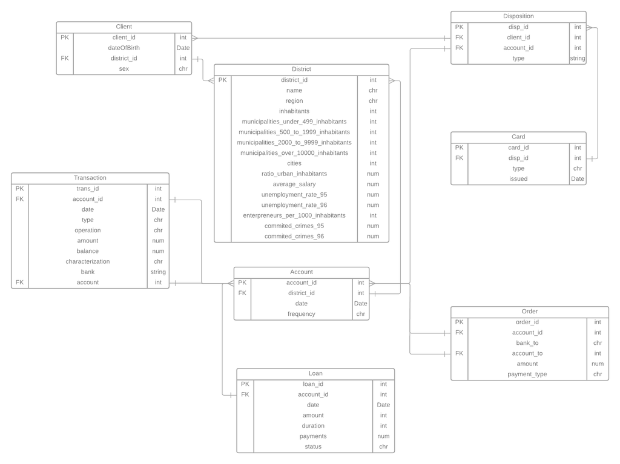

ERD Daten IST-Zustand

## 1. Tabellen zusammenführen und erste Analysen

### Tabellen zusammenführen

Das Data Frame Account steht im Zentrum und beinhaltet die Schlüsselfelder zu fast allen weiteren Tabellen. Deshalb beginnen wir mit dem Account und dem District.

```r
df <- left_join(df_account, df_district, by = c("district_id"), suffix = c(".df", ".district"))
```

Nun werden die Tabellen Loan, Order und Disposition angefügt:

```r
df <- left_join(df, df_loan, by = c("account_id"), suffix = c(".df", ".loan"))
df <- left_join(df, df_perm_order, by = c("account_id"), suffix = c(".df", ".order"))
df <- left_join(df, df_disposition, by = c("account_id"), suffix = c(".df", ".disposition"))
```

Nun kann die Tabelle mit den Kreditkarten angefügt werden

```r
df <- left_join(df, df_credit_card, by = c("disp_id"), suffix = c(".df", ".card"))
```

Es fehlen noch der Client

```r
df <- left_join(df, df_client, by = c("client_id", "district_id"), suffix = c(".df", ".client"))
```

und die Tabelle mit den Transaktionen

```r
df <- left_join(df, df_transaction, by = c("account_id"), suffix = c(".df", ".transaction"))
```

Nachdem alle Tabellen aneinander gefügt wurden kann das neue Data Frame inspiziert werden.

```r
glimpse(df)
```

```
## Rows: 2,243,458
## Columns: 47
## $ account_id                              <int> 1, 1, 1, 1, 1, 1, 1, 1, 1, 1, …
## $ district_id                             <int> 18, 18, 18, 18, 18, 18, 18, 18…
## $ frequency                               <chr> "Monthly", "Monthly", "Monthly…
## $ date.df                                 <date> 1995-03-24, 1995-03-24, 1995-…
## $ name                                    <chr> "Pisek", "Pisek", "Pisek", "Pi…
## $ region                                  <chr> "south Bohemia", "south Bohemi…
## $ inhabitants                             <int> 70699, 70699, 70699, 70699, 70…
## $ municipalities_under_499_inhabitants    <int> 60, 60, 60, 60, 60, 60, 60, 60…
## $ municipalities_500_to_1999_inhabitants  <int> 13, 13, 13, 13, 13, 13, 13, 13…
## $ municipalities_2000_to_9999_inhabitants <int> 2, 2, 2, 2, 2, 2, 2, 2, 2, 2, …
## $ municipalities_over_10000_inhabitants   <int> 2, 2, 2, 2, 2, 2, 2, 2, 2, 2, …
## $ cities                                  <int> 4, 4, 4, 4, 4, 4, 4, 4, 4, 4, …
## $ ratio_urban_inhabitants                 <dbl> 65.3, 65.3, 65.3, 65.3, 65.3, …
```

[output cut: 34 more lines]

### Attribute anpassen

Folgende Attribute werden angepasst: unemployment_rate_95 zu “num” commited_crimes_95 zu “int” alle chr zu factor

```r
df <- df %>%
  mutate(
    across(c("unemployment_rate_95"), as.numeric),
    across(c("commited_crimes_95"), as.integer),
    across(where(is.character), as.factor))


str(df)
```

```
## 'data.frame':    2243458 obs. of  47 variables:
##  $ account_id                             : int  1 1 1 1 1 1 1 1 1 1 ...
##  $ district_id                            : int  18 18 18 18 18 18 18 18 18 18 ...
##  $ frequency                              : Factor w/ 3 levels "After_Transaction",..: 2 2 2 2 2 2 2 2 2 2 ...
##  $ date.df                                : Date, format: "1995-03-24" "1995-03-24" ...
##  $ name                                   : Factor w/ 77 levels "Benesov","Beroun",..: 47 47 47 47 47 47 47 47 47 47 ...
##  $ region                                 : Factor w/ 8 levels "central Bohemia",..: 6 6 6 6 6 6 6 6 6 6 ...
##  $ inhabitants                            : int  70699 70699 70699 70699 70699 70699 70699 70699 70699 70699 ...
##  $ municipalities_under_499_inhabitants   : int  60 60 60 60 60 60 60 60 60 60 ...
##  $ municipalities_500_to_1999_inhabitants : int  13 13 13 13 13 13 13 13 13 13 ...
##  $ municipalities_2000_to_9999_inhabitants: int  2 2 2 2 2 2 2 2 2 2 ...
##  $ municipalities_over_10000_inhabitants  : int  2 2 2 2 2 2 2 2 2 2 ...
##  $ cities                                 : int  4 4 4 4 4 4 4 4 4 4 ...
##  $ ratio_urban_inhabitants                : num  65.3 65.3 65.3 65.3 65.3 65.3 65.3 65.3 65.3 65.3 ...
##  $ average_salary                         : int  8968 8968 8968 8968 8968 8968 8968 8968 8968 8968 ...
```

[output cut: 33 more lines]

```r
df %>%
  map(summary)
```

```
## $account_id
##    Min. 1st Qu.  Median    Mean 3rd Qu.    Max.
##       1    1251    2503    3095    3769   11382
##
## $district_id
##    Min. 1st Qu.  Median    Mean 3rd Qu.    Max.
##    1.00   13.00   38.00   37.24   61.00   77.00
##
## $frequency
## After_Transaction           Monthly            Weekly
##             50810           2047360            145288
##
## $date.df
##         Min.      1st Qu.       Median         Mean      3rd Qu.         Max.
## "1993-01-01" "1993-07-25" "1994-07-23" "1994-11-13" "1996-03-15" "1997-12-29"
##
## $name
##             Benesov              Beroun             Blansko             Breclav
##               23246               18108               26685               23564
##        Brno - mesto       Brno - venkov             Bruntal          Ceska Lipa
##               64037               28045               22467               23792
##    Ceske Budejovice       Cesky Krumlov                Cheb            Chomutov
##               19078               24800               23418               18845
##             Chrudim               Decin           Domazlice     Frydek - Mistek
##               16759               26876               18708               50901
##      Havlickuv Brod         Hl.m. Praha             Hodonin      Hradec Kralove
##               19170              289675               19378               20502
##   Jablonec n. Nisou             Jesenik               Jicin             Jihlava
##               20971               18931               23778               13582
##   Jindrichuv Hradec        Karlovy Vary             Karvina              Kladno
##               21196               31631               71765               23675
##             Klatovy               Kolin            Kromeriz          Kutna Hora
##               17230               29850               27847               28998
##             Liberec          Litomerice               Louny              Melnik
##               25739               19423               34382               24448
##      Mlada Boleslav                Most              Nachod          Novy Jicin
##               23442               20708               20949               15728
##             Nymburk             Olomouc               Opava     Ostrava - mesto
##               25508               41972               29431               81310
##           Pardubice           Pelhrimov               Pisek         Plzen - jih
```

[output cut: 188 more lines]

```
## $characterization
##    CREDIT INTEREST          HOUSEHOLD INSURRANCE PAYMENT       LOAN PAYMENT
##             357024             258700              82177              36422
##    OLD AGE PENSION  SANCTION INTEREST  STATEMENT PAYMENT               NA's
##              46311               2144             304053            1156627
##
## $bank
##              AB      CD      EF      GH      IJ      KL      MN      OP      QR
## 1534492   56123   51335   54498   55347   55267   55556   49201   54005   55821
##      ST      UV      WX      YZ
##   56356   52728   55203   57526
##
## $account
##     Min.  1st Qu.   Median     Mean  3rd Qu.     Max.     NA's
##        0 18812161 46939146 46459236 72882389 99994199  1486774
```

### Attribute umbenennen

```r
df <- rename(df,
    'account_date' = 'date.df',
    'district_name' = 'name',
    'loan_date' = 'date.loan',
    'loan_amount' = 'amount.df',
    'loan_duration' = 'duration',
    'loan_payments' = 'payments',
    'loan_status' = 'status',
    'order_amount' = 'amount.order',
    'order_payment_type' = 'payment_type',
    'disp_type' = 'type.df',
    'card_type' = 'type.card',
    'card_issued' = 'issued',
    'trans_date' = 'date',
    'trans_type' = 'type',
    'account_frequency' = 'frequency'
  )
```

Weitere Spalten umbenennen, damit sie später einfacher zugeordnet und angewählt werden können:

```r
df <- rename(df,
    'trans_operation' = 'operation',
    'trans_amount' = 'amount',
    'trans_balance' = 'balance',
    'trans_characterization' = 'characterization',
    'trans_bank' = 'bank',
    'trans_account' = 'account'
  )
```

### Sonderstellung der Werte aus distribution type

Wie wir bei der Datenbeschreibung bereits gelesen haben, enthält disposition_type die Information über die Rechte der Konten. Deshalb wird nun der Eintrag “disponent” in “user” geändert. Denn nur der “owner” hat die nötigen Berechtigungen, um Daueraufträge zu erteilen und Darlehen zu beantragen.

```r
levels(df$disp_type)
```

```
## [1] "DISPONENT" "OWNER"
```

```r
df <- df %>%
  mutate(
    disp_type = case_when(
      disp_type == "OWNER" ~"OWNER",
      disp_type == "DISPONENT" ~ "USER"
    )) %>%
  mutate(across(where(is.character), as.factor))

levels(df$disp_type)
```

```
## [1] "OWNER" "USER"
```

### Auf Duplikate überprüfen

```r
n_distinct(df)
```

```
## [1] 2243458
```

Es sind keine Duplikate vorhanden.

### Erste Analysen

Nun werden die Transaktionen genauer untersucht. Dazu wird Data Frame erstellt mit den relevanten Spalten aus Transaktionen, Loan, Order, Account und Credit Card.

```r
transactions <- df %>%
  select(
    account_id,
    starts_with('trans'),
    ends_with('to'),
    starts_with('loan'),
    starts_with('order'),
    starts_with('card'),
    )
head(transactions)
```

```
##   account_id trans_id trans_date trans_type       trans_operation trans_amount
## 1          1        1 1995-03-24     CREDIT           CASH CREDIT         1000
## 2          1        5 1995-04-13     CREDIT COLLECTION OTHER BANK         3679
## 3          1        6 1995-05-13     CREDIT COLLECTION OTHER BANK         3679
## 4          1        7 1995-06-13     CREDIT COLLECTION OTHER BANK         3679
## 5          1        8 1995-07-13     CREDIT COLLECTION OTHER BANK         3679
## 6          1        9 1995-08-13     CREDIT COLLECTION OTHER BANK         3679
##   trans_balance trans_characterization trans_bank trans_account bank_to
## 1        1000.0                   <NA>                       NA      YZ
## 2        4679.0                   <NA>         AB      41403269      YZ
## 3       20977.2                   <NA>         AB      41403269      YZ
## 4       26835.2                   <NA>         AB      41403269      YZ
## 5       30414.8                   <NA>         AB      41403269      YZ
## 6       28902.7                   <NA>         AB      41403269      YZ
##   account_to loan_id loan_date loan_amount loan_duration loan_payments
```

[output cut: 20 more lines]

Das neue Data Frame transactions kann nun inspiziert werden.

```r
transactions %>%
  map(summary)
```

```
## $account_id
##    Min. 1st Qu.  Median    Mean 3rd Qu.    Max.
##       1    1251    2503    3095    3769   11382
##
## $trans_id
##    Min. 1st Qu.  Median    Mean 3rd Qu.    Max.
##       1  432252  864844 1338906 2256254 3682987
##
## $trans_date
##         Min.      1st Qu.       Median         Mean      3rd Qu.         Max.
## "1993-01-01" "1996-01-16" "1997-04-12" "1997-01-05" "1998-02-28" "1998-12-31"
##
## $trans_type
##     CREDIT WITHDRAWAL       NA's
##     789743    1420547      33168
##
## $trans_operation
##            CASH CREDIT       CASH WIDTHDRAWAL  COLLECTION OTHER BANK
##                 311688                 850581                 121031
## CREDIT CARD WITHDRAWAL  REMITTANCE OTHER BANK                   NA's
##                  15198                 587936                 357024
##
## $trans_amount
##    Min. 1st Qu.  Median    Mean 3rd Qu.    Max.
##       0     148    1950    5763    6561   87400
##
## $trans_balance
##    Min. 1st Qu.  Median    Mean 3rd Qu.    Max.
##  -41126   22998   34025   39131   50268  209637
##
## $trans_characterization
##    CREDIT INTEREST          HOUSEHOLD INSURRANCE PAYMENT       LOAN PAYMENT
##             357024             258700              82177              36422
##    OLD AGE PENSION  SANCTION INTEREST  STATEMENT PAYMENT               NA's
##              46311               2144             304053            1156627
##
## $trans_bank
##              AB      CD      EF      GH      IJ      KL      MN      OP      QR
## 1534492   56123   51335   54498   55347   55267   55556   49201   54005   55821
##      ST      UV      WX      YZ
```

[output cut: 54 more lines]

```
##    1040813     205055     102550     237892     501555     155593
##
## $card_id
##    Min. 1st Qu.  Median    Mean 3rd Qu.    Max.    NA's
##     1.0   251.0   493.0   513.8   727.0  1247.0 1850830
##
## $card_type
## CLASSIC    GOLD  JUNIOR    NA's
##  286792   42735   63101 1850830
##
## $card_issued
##         Min.      1st Qu.       Median         Mean      3rd Qu.         Max.
## "1993-11-07" "1996-09-11" "1997-09-22" "1997-06-13" "1998-06-24" "1998-12-29"
##         NA's
##    "1850830"
```

### Untersuchen von NA’s

Um die NA’s zu untersuchen beginne ich mit den Spalten der Transaktionen, welche für die Art der Transaktion verwendet werden. Es sind dies der type, operation und characterization.

Überprüfen, welche Levels in “type” verwendet werden:

```r
levels(transactions$trans_type)
```

```
## [1] "CREDIT"     "WITHDRAWAL"
```

Die Spalte trans_type weist zwei Levels auf, wobei es sich bei CREDIT um Gutschriften und bei WITHDRAWAL um Rückzüge handelt.

```r
count(transactions, trans_type)
```

```
##   trans_type       n
## 1     CREDIT  789743
## 2 WITHDRAWAL 1420547
## 3       <NA>   33168
```

An diesem Beispiel ist sehr gut zu erkennen, wie sich die verschiedenen Levels zueinander verhalten.

```r
transactions %>%
  filter(
    account_id == 1
  ) %>%
  select(
    account_id,
    trans_date,
    trans_amount,
    trans_balance,
    trans_type,
    trans_operation,
    trans_characterization
  ) %>%
  arrange(trans_date) %>%
  head()
```

```
##   account_id trans_date trans_amount trans_balance trans_type
## 1          1 1995-03-24       1000.0        1000.0     CREDIT
## 2          1 1995-04-13       3679.0        4679.0     CREDIT
## 3          1 1995-04-23      12600.0       17279.0     CREDIT
## 4          1 1995-04-30         19.2       17298.2     CREDIT
## 5          1 1995-05-13       3679.0       20977.2     CREDIT
## 6          1 1995-05-23       2100.0       23077.2     CREDIT
##         trans_operation trans_characterization
## 1           CASH CREDIT                   <NA>
## 2 COLLECTION OTHER BANK                   <NA>
## 3           CASH CREDIT                   <NA>
## 4                  <NA>        CREDIT INTEREST
## 5 COLLECTION OTHER BANK                   <NA>
## 6           CASH CREDIT                   <NA>
```

Für einen besseren Überblick werden relevante Spalten ausgewählt und verglichen.

```r
transactions %>%
  select(
    trans_type,
    trans_operation,
    trans_characterization,
    order_payment_type,
    loan_payments,
    loan_status,
    loan_duration,
  ) %>%
  filter(
    is.na(trans_type)
  ) %>%
  summary()
```

```
##       trans_type                  trans_operation
##  CREDIT    :    0   CASH CREDIT           :    0
##  WITHDRAWAL:    0   CASH WIDTHDRAWAL      :33168
##  NA's      :33168   COLLECTION OTHER BANK :    0
##                     CREDIT CARD WITHDRAWAL:    0
##                     REMITTANCE OTHER BANK :    0
##
##
##         trans_characterization  order_payment_type loan_payments
##  CREDIT INTEREST   :    0      HOUSEHOLD :9206     Min.   :1671
##  HOUSEHOLD         :    0      INSURRANCE:2294     1st Qu.:3208
##  INSURRANCE PAYMENT:    0      LEASING   :4222     Median :4363
##  LOAN PAYMENT      :    0      LOAN      :7659     Mean   :4650
##  OLD AGE PENSION   :    0      UNKNOWN   :5445     3rd Qu.:6150
##  (Other)           :    0      NA's      :4342     Max.   :8308
##  NA's              :33168                          NA's   :18818
##                    loan_status    loan_duration
##  CONTRACT FINISHED PAYED : 6395   Min.   :12.00
##  CONTRACT FINISHED UNPAID:  685   1st Qu.:24.00
##  CONTRACT OPEN INDEBT    :  617   Median :36.00
##  CONTRACT OPEN OK        : 6653   Mean   :34.34
##  NA's                    :18818   3rd Qu.:48.00
##                                   Max.   :60.00
##                                   NA's   :18818
```

Die Anzahl NA’s (33168) ist bei trans_type, und trans_characterization gleich hoch und dafür ist die Anzahl “CASH WIDTHDRAWAL” bei trans_operation mit 33168 ebeso gross. Es könnte sein, dass es sich hier überall um Bargeldbezüge handelt. Dies wird nun genauer angeschaut.

```r
transactions %>%
  select(
    trans_type,
    trans_operation,
    trans_characterization,
    order_payment_type,
    loan_status,
    loan_duration,
  ) %>%
  filter(
    is.na(trans_type),
    is.na(trans_characterization)
  ) %>%
  slice_sample(n = 5)
```

```
##   trans_type  trans_operation trans_characterization order_payment_type
## 1       <NA> CASH WIDTHDRAWAL                   <NA>          HOUSEHOLD
## 2       <NA> CASH WIDTHDRAWAL                   <NA>            UNKNOWN
## 3       <NA> CASH WIDTHDRAWAL                   <NA>            UNKNOWN
## 4       <NA> CASH WIDTHDRAWAL                   <NA>            LEASING
## 5       <NA> CASH WIDTHDRAWAL                   <NA>            UNKNOWN
##                loan_status loan_duration
## 1         CONTRACT OPEN OK            48
## 2                     <NA>            NA
## 3 CONTRACT FINISHED UNPAID            12
## 4                     <NA>            NA
## 5  CONTRACT FINISHED PAYED            24
```

Alle NA’s in trans_type sind Geldrückzüge/Bezüge. Diese Variable kann entsprechend angepasst werden. Für die richtige Zuordnung der Variablen in trans_characterization braucht es weitere Analysen.

### Erstes Anpassen der Variablen

Da es sich bei den Variablen in trans_type um Geldein- und ausgänge handelt, werden alle Variablen folgendermassen umbenannt: Attributname “type” zu “cashflow” CREDIT zu IN WITHDRAWAL zu OUT NA’s zu OUT

```r
df_mod <- df %>%
  rename(
    order_bank_to = bank_to,
    order_account_to = account_to
    ) %>%
  mutate(
   trans_cashflow = case_when(trans_type == "WITHDRAWAL" ~ "OUT",
                              trans_type == "CREDIT" ~ "IN",
                              TRUE ~ "OUT"
    )
  ) %>%
  mutate(across(where(is.character), as.factor))

summary(df_mod$trans_cashflow)
```

```
##      IN     OUT
##  789743 1453715
```

Die NA’s im Attribut “characterization” sind nicht nur Bargeldbezüge wie wir es in der Analyse von vorhin festgestllt haben. Nun werden diese NA’s weiter untersucht. Vergleich der beiden Attribute trans_operation und trans_characterization.

```r
transactions <- df_mod %>%
  select(
    account_id,
    starts_with('trans'),
    starts_with('loan'),
    starts_with('order'),
    starts_with('card'),
    )

summary(transactions[, c("trans_operation", "trans_characterization")])
```

```
##                trans_operation          trans_characterization
##  CASH CREDIT           :311688   CREDIT INTEREST   : 357024
##  CASH WIDTHDRAWAL      :850581   STATEMENT PAYMENT : 304053
##  COLLECTION OTHER BANK :121031   HOUSEHOLD         : 258700
##  CREDIT CARD WITHDRAWAL: 15198   INSURRANCE PAYMENT:  82177
##  REMITTANCE OTHER BANK :587936   OLD AGE PENSION   :  46311
##  NA's                  :357024   (Other)           :  38566
##                                  NA's              :1156627
```

Es fällt auf, dass die Anzahl NA’s (357024) aus trans_operation mit der Anzahl CREDIT INTEREST aus trans_characterization korrespondiert. Dies wollen wir nun genauer untersuchen.

Dabei sollen folgende Fragen beantwortet werden: 1. besteht eine Abhängigkeit zwischen NA’s aus “operation” und “CREDIT INTEREST” aus “characterization? 2. welche Abhängigkeiten bestehen zwischen”CASH WIDTHDRAWAL” aus “operation” und den Einträgen in “characterization”?

Diese Fragen werden in den Folgenden Analysen beantwortet.

### Punkt 1:

Besteht eine Abhängigkeit zwischen NA’s aus “operation” und “CREDIT INTEREST” aus “characterization?

```r
transactions %>%
 filter(
    is.na(trans_operation)
  ) %>%
  select(
    trans_operation,
    trans_characterization
  ) %>%
  summary()
```

```
##                trans_operation          trans_characterization
##  CASH CREDIT           :     0   CREDIT INTEREST   :357024
##  CASH WIDTHDRAWAL      :     0   HOUSEHOLD         :     0
##  COLLECTION OTHER BANK :     0   INSURRANCE PAYMENT:     0
##  CREDIT CARD WITHDRAWAL:     0   LOAN PAYMENT      :     0
##  REMITTANCE OTHER BANK :     0   OLD AGE PENSION   :     0
##  NA's                  :357024   SANCTION INTEREST :     0
##                                  STATEMENT PAYMENT :     0
```

Die NA’s in “operation” sind “CREDIT INTEREST” aus “trans_characterization”. Um dies genauer zu verstehen, müssen diese Variablen im gesamten Data Frame angeschaut werden.

```r
transactions %>%
   filter(
    is.na(trans_operation)
  ) %>%
  slice_sample(n = 5)
```

```
##   account_id trans_id trans_date trans_type trans_operation trans_amount
## 1       1291  3573037 1997-10-31     CREDIT            <NA>         58.9
## 2       2799  3623010 1994-06-30     CREDIT            <NA>        270.3
## 3       2599  3448259 1998-05-31     CREDIT            <NA>        309.8
## 4       4418  3664482 1994-05-31     CREDIT            <NA>        140.0
## 5       1879  3592557 1998-01-31     CREDIT            <NA>         58.3
##   trans_balance trans_characterization trans_bank trans_account trans_cashflow
## 1       13331.2        CREDIT INTEREST                       NA             IN
## 2       99083.8        CREDIT INTEREST                       NA             IN
## 3       99541.3        CREDIT INTEREST                       NA             IN
## 4       35900.2        CREDIT INTEREST                       NA             IN
## 5       13831.7        CREDIT INTEREST                       NA             IN
##   loan_id loan_date loan_amount loan_duration loan_payments loan_status
## 1      NA      <NA>          NA            NA            NA        <NA>
## 2      NA      <NA>          NA            NA            NA        <NA>
## 3      NA      <NA>          NA            NA            NA        <NA>
## 4      NA      <NA>          NA            NA            NA        <NA>
## 5      NA      <NA>          NA            NA            NA        <NA>
##   order_id order_bank_to order_account_to order_amount order_payment_type
## 1    31291            OP         71369182         1333          HOUSEHOLD
## 2    33542            WX          8040637         4870            UNKNOWN
## 3       NA          <NA>               NA           NA               <NA>
## 4    35889            UV         51602697          906         INSURRANCE
## 5    32148            WX         53768026          907          HOUSEHOLD
##   card_id card_type card_issued
## 1      NA      <NA>        <NA>
## 2     532   CLASSIC  1997-11-30
## 3     489   CLASSIC  1998-11-29
## 4      NA      <NA>        <NA>
## 5      NA      <NA>        <NA>
```

Es handelt sich hier um Gutschriften. Diese Guthabenzinsen können in der Variable “operation” somit entsprechend angepasst werden.

### Zweites Anpassen der Variablen

Die Variable (NA’s in trans_operation) wird angepasst.

```r
df_mod <- df_mod %>%
  mutate(
    trans_operation_case = case_when(
      trans_operation == "CASH CREDIT" ~ "CASH CREDIT",
      trans_operation == "CASH WIDTHDRAWAL" ~ "CASH WIDTHDRAWAL",
      trans_operation == "COLLECTION OTHER BANK" ~ "COLLECTION OTHER BANK",
      trans_operation == "CREDIT CARD WITHDRAWAL" ~ "CREDIT CARD WITHDRAWAL",
      trans_operation == "REMITTANCE OTHER BANK" ~ "REMITTANCE OTHER BANK",
      TRUE ~ "CREDIT INTEREST"
    )
  )%>%
  mutate(across(where(is.character), as.factor))

summary(df_mod$trans_operation_case)
```

```
##            CASH CREDIT       CASH WIDTHDRAWAL  COLLECTION OTHER BANK
##                 311688                 850581                 121031
## CREDIT CARD WITHDRAWAL        CREDIT INTEREST  REMITTANCE OTHER BANK
##                  15198                 357024                 587936
```

Erneuter Überblick über die beiden Spalten

```r
df_mod %>%
  select(
    trans_operation_case,
    trans_characterization
  ) %>%
  summary()
```

```
##              trans_operation_case        trans_characterization
##  CASH CREDIT           :311688    CREDIT INTEREST   : 357024
##  CASH WIDTHDRAWAL      :850581    STATEMENT PAYMENT : 304053
##  COLLECTION OTHER BANK :121031    HOUSEHOLD         : 258700
##  CREDIT CARD WITHDRAWAL: 15198    INSURRANCE PAYMENT:  82177
##  CREDIT INTEREST       :357024    OLD AGE PENSION   :  46311
##  REMITTANCE OTHER BANK :587936    (Other)           :  38566
##                                   NA's              :1156627
```

Für die NA’s aus trans_characterization braucht es weiterführende Analysen. Dazu filtern wir die NA’s und vergleichen mit den weiteren relevanten Spalten in Bezug auf die Geldflüsse.

```r
characterization_NA <- df_mod %>%
  select(
    trans_cashflow,
    account_id,
    trans_operation_case,
    order_payment_type,
    card_issued,
    card_type,
    trans_characterization
  ) %>%
  filter(
    is.na(trans_characterization)
  )

slice_sample(characterization_NA, n = 5)
```

```
##   trans_cashflow account_id  trans_operation_case order_payment_type
## 1            OUT        441      CASH WIDTHDRAWAL            LEASING
## 2             IN       2161           CASH CREDIT          HOUSEHOLD
## 3             IN       1233 COLLECTION OTHER BANK          HOUSEHOLD
## 4             IN       2170           CASH CREDIT         INSURRANCE
## 5            OUT       1250      CASH WIDTHDRAWAL            UNKNOWN
##   card_issued card_type trans_characterization
## 1        <NA>      <NA>                   <NA>
## 2        <NA>      <NA>                   <NA>
## 3        <NA>      <NA>                   <NA>
## 4  1998-02-28   CLASSIC                   <NA>
## 5        <NA>      <NA>                   <NA>
```

ev. werden die Zusammenhänge mit Gruppieren übersichtlicher:

```r
characterization_NA %>%
  group_by(
    trans_operation_case,
    order_payment_type
  ) %>%
  count() %>%
  arrange(desc(n)) %>%
  head()
```

```
## # A tibble: 6 × 3
## # Groups:   trans_operation_case, order_payment_type [6]
##   trans_operation_case  order_payment_type      n
##   <fct>                 <fct>               <int>
## 1 CASH WIDTHDRAWAL      HOUSEHOLD          244077
## 2 CASH CREDIT           HOUSEHOLD          124843
## 3 CASH WIDTHDRAWAL      UNKNOWN            106619
## 4 REMITTANCE OTHER BANK HOUSEHOLD           81248
## 5 REMITTANCE OTHER BANK UNKNOWN             81193
## 6 CASH CREDIT           UNKNOWN             68292
```

Zum Vergleich wird dieselbe Aufstellung gemacht aber diesmal ohne die NA’s auch trans_characterization

```r
df_mod %>%
  filter(
    !is.na(trans_characterization)
  ) %>%
  group_by(
    trans_operation_case,
    order_payment_type,
    trans_characterization
  ) %>%
  count() %>%
  arrange(desc(n)) %>%
  head()
```

```
## # A tibble: 6 × 4
## # Groups:   trans_operation_case, order_payment_type, trans_characterization
## #   [6]
##   trans_operation_case  order_payment_type trans_characterization      n
##   <fct>                 <fct>              <fct>                   <int>
## 1 CREDIT INTEREST       HOUSEHOLD          CREDIT INTEREST        172451
## 2 CASH WIDTHDRAWAL      HOUSEHOLD          STATEMENT PAYMENT      151773
## 3 REMITTANCE OTHER BANK HOUSEHOLD          HOUSEHOLD              146779
## 4 CREDIT INTEREST       UNKNOWN            CREDIT INTEREST         70019
## 5 CASH WIDTHDRAWAL      UNKNOWN            STATEMENT PAYMENT       60046
## 6 REMITTANCE OTHER BANK UNKNOWN            HOUSEHOLD               58038
```

Es gibt 37 verschiedene Kombinationen. Diese alle im Detail zu analysieren würde den aktuellen Rahmen sprengen. Deshalb wird hier vorerst darauf verzichtet und bei den zukünftigen Analysen jeweils die relevanten Spalten miteinbezogen. Eventuell bietet es sich an, zu einem späteren Zeitpunkt neue Attribute mit entprechenden Variablen zu erstellen.

### Punkt 2:

Welche Abhängigkeiten bestehen zwischen “CASH WIDTHDRAWAL” aus “operation” und den Einträgen in “characterization”?

```r
df_mod %>%
  filter(
    trans_operation_case == "CASH WIDTHDRAWAL"
  ) %>%
  select(
    trans_operation_case,
    trans_characterization
  ) %>%
  summary()
```

```
##              trans_operation_case        trans_characterization
##  CASH CREDIT           :     0    STATEMENT PAYMENT :304053
##  CASH WIDTHDRAWAL      :850581    HOUSEHOLD         :  2866
##  COLLECTION OTHER BANK :     0    SANCTION INTEREST :  2144
##  CREDIT CARD WITHDRAWAL:     0    INSURRANCE PAYMENT:    23
##  CREDIT INTEREST       :     0    CREDIT INTEREST   :     0
##  REMITTANCE OTHER BANK :     0    (Other)           :     0
##                                   NA's              :541495
```

Dies sieht auch nach einer umfassenden Analyse aus, was zum aktuellen Zeitpunkt nicht zielführend ist.

### Überprüfung auf doppelte Werte in den Transaktionen

```r
df_mod %>%
 arrange(desc(trans_id)) %>%
  head()
```

```
##   account_id district_id account_frequency account_date district_name region
## 1      10451           1           Monthly   1993-08-29   Hl.m. Praha Prague
## 2      10451           1           Monthly   1993-08-29   Hl.m. Praha Prague
## 3      10451           1           Monthly   1993-08-29   Hl.m. Praha Prague
## 4      10451           1           Monthly   1993-08-29   Hl.m. Praha Prague
## 5      10451           1           Monthly   1993-08-29   Hl.m. Praha Prague
## 6      10451           1           Monthly   1993-08-29   Hl.m. Praha Prague
##   inhabitants municipalities_under_499_inhabitants
## 1     1204953                                    0
## 2     1204953                                    0
## 3     1204953                                    0
## 4     1204953                                    0
## 5     1204953                                    0
## 6     1204953                                    0
##   municipalities_500_to_1999_inhabitants
```

[output cut: 69 more lines]

```r
x <- df_mod %>%
  filter(
    trans_id == 3682987
  )
x
```

```
##   account_id district_id account_frequency account_date district_name region
## 1      10451           1           Monthly   1993-08-29   Hl.m. Praha Prague
## 2      10451           1           Monthly   1993-08-29   Hl.m. Praha Prague
## 3      10451           1           Monthly   1993-08-29   Hl.m. Praha Prague
## 4      10451           1           Monthly   1993-08-29   Hl.m. Praha Prague
##   inhabitants municipalities_under_499_inhabitants
## 1     1204953                                    0
## 2     1204953                                    0
## 3     1204953                                    0
## 4     1204953                                    0
##   municipalities_500_to_1999_inhabitants
## 1                                      0
## 2                                      0
## 3                                      0
## 4                                      0
```

[output cut: 45 more lines]

Die Überprüfung der korrekten Zusammensetzung der einzelnen Data Frames verlief positiv. Nun kann das konsolidierte Data Frame für die weitere Arbeit erstellt werden.

### **Erstellen des konsolidierten Data Frames**

Das konsolidierte Data Frame wird und dem Namen **df_cons** gespeichert.

```r
df_cons <- df_mod %>%
  select(
    -trans_type,
    -trans_operation
  ) %>%
  rename(
    "trans_operation" = "trans_operation_case"
  ) %>%
  relocate(
    starts_with("account"),
    starts_with("trans"),
    starts_with("order"),
    starts_with("loan"),
    starts_with("card"),
    starts_with("disp"),
    client_id,
    dateofbirth,
    sex
  )
```

Übersicht über die Struktur des konsolidierten Datensatzes.

```r
str(df_cons)
```

```
## 'data.frame':    2243458 obs. of  47 variables:
##  $ account_id                             : int  1 1 1 1 1 1 1 1 1 1 ...
##  $ account_frequency                      : Factor w/ 3 levels "After_Transaction",..: 2 2 2 2 2 2 2 2 2 2 ...
##  $ account_date                           : Date, format: "1995-03-24" "1995-03-24" ...
##  $ trans_id                               : int  1 5 6 7 8 9 10 11 12 13 ...
##  $ trans_date                             : Date, format: "1995-03-24" "1995-04-13" ...
##  $ trans_amount                           : num  1000 3679 3679 3679 3679 ...
##  $ trans_balance                          : num  1000 4679 20977 26835 30415 ...
##  $ trans_characterization                 : Factor w/ 7 levels "CREDIT INTEREST",..: NA NA NA NA NA NA NA NA NA NA ...
##  $ trans_bank                             : Factor w/ 14 levels "","AB","CD","EF",..: 1 2 2 2 2 2 2 2 2 2 ...
##  $ trans_account                          : int  NA 41403269 41403269 41403269 41403269 41403269 41403269 41403269 41403269 41403269 ...
##  $ trans_cashflow                         : Factor w/ 2 levels "IN","OUT": 1 1 1 1 1 1 1 1 1 1 ...
##  $ trans_operation                        : Factor w/ 6 levels "CASH CREDIT",..: 1 3 3 3 3 3 3 3 3 3 ...
##  $ order_id                               : int  29401 29401 29401 29401 29401 29401 29401 29401 29401 29401 ...
##  $ order_bank_to                          : Factor w/ 13 levels "AB","CD","EF",..: 13 13 13 13 13 13 13 13 13 13 ...
```

[output cut: 33 more lines]

## 1. Datengrundlage

Die uns zu Grunde liegenden Daten lassen sich als von der Bank sowie als exogen erhoben unterscheiden.

### a. Wie können die Daten noch weiter gruppiert und angeordnet werden, um eine optimale Grundlage für die Analyse zu bilden? (Luca)

### b. Wie umfassend sind die Stichproben der Daten der Bank? Und trifft dies für alle einzelnen Datensätze zu? (Luca)

### Zudem wird die Distribution der Datensätze und deren Qualität überprüft. (Luca)

### c. Die Datenattribute werden alle auf ihre Verteilung sowie ihre Veränderung über die Zeit analysiert. Dabei werden technische Mittel der explorativen Datenanalyse angewendet. (Luca)

#### i. Jegliche Datenattribute werden innerhalb des eigenen Datenrahmens analysiert. (Luca)

## 2. Korrelationsanalysen

Nachdem die Datenattribute einzeln analysiert und geprüft wurden, sollen sie miteinander mittels Korrelationsanalysen betrachtet werden. Dabei sollten anfällige Zusammenhänge entdeckt werden.  
Beispiele für Hypothesen, welche in der Analyse überprüft werden könnten, wären:

### a. Für die einzelne Datenattribute:

#### i. In welchem Monat oder Tag wird am meisten Geld abgehoben? (LBZ)

Levels vom Attribut trans_operation ausgeben:

```r
levels(df_cons$trans_operation)
```

```
## [1] "CASH CREDIT"            "CASH WIDTHDRAWAL"       "COLLECTION OTHER BANK"
## [4] "CREDIT CARD WITHDRAWAL" "CREDIT INTEREST"        "REMITTANCE OTHER BANK"
```

Es gibt zwei verschiedene Arten von Geldabbuchungen. Erstere ist die Geldabbuchung beziehungsweise Überweisung und die zweite die Abbuchung mittels Kreditkarte. Diese beiden Arten werden getrennt analysiert.

```r
outgoes <- df_cons %>%
  filter(
    trans_cashflow == "OUT"
  ) %>%
  mutate(
    trans_year = year(trans_date),
    trans_month = month(trans_date),
    trans_day = day(trans_date)
  )

cash_withdrawal <- outgoes %>%
  filter(
    trans_operation == "CASH WIDTHDRAWAL"
  )

card_withdrawal <- outgoes %>%
  filter(
    trans_operation == "CREDIT CARD WITHDRAWAL"
  )

n_cash <- nrow(cash_withdrawal)
n_card <- nrow(card_withdrawal)

paste("Es wurden", n_cash, "Abbuchungen und", n_card, "Kreditkatenbezüge getätigt.", sep = " ")
```

```
## [1] "Es wurden 850581 Abbuchungen und 15198 Kreditkatenbezüge getätigt."
```

Für die weiteren Analysen wird eine zusätzliche Spalte für die Quartale eines Jahres benötigt. Dazu wird das Jahr in vier Quartale unterteilt.

```r
summary(outgoes$trans_month)
```

```
##    Min. 1st Qu.  Median    Mean 3rd Qu.    Max.
##   1.000   3.000   7.000   6.525  10.000  12.000
```

```r
outgoes <- outgoes %>%
  mutate(
    period = case_when(
      (trans_month <= 3) ~ "1. QUARTER",
      (trans_month >= 4 & trans_month <= 6) ~ "2. QUARTER",
      (trans_month >= 7 & trans_month <= 9) ~ "3. QUARTER",
      (trans_month > 9) ~ "4. QUARTER"
    ),
    across(
      where(is.character),
      as.factor
       )
  )

summary(outgoes$period)
```

```
## 1. QUARTER 2. QUARTER 3. QUARTER 4. QUARTER
##     381247     331934     346838     393696
```

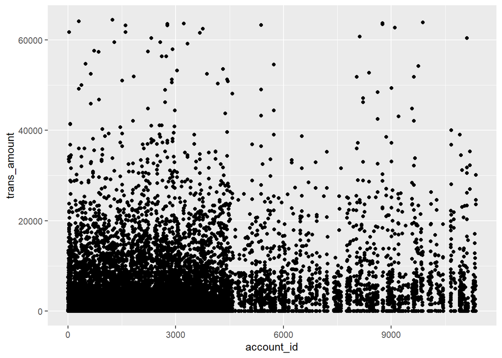

```r
cash_withdrawal <- outgoes %>%
  filter(
    trans_operation == "CASH WIDTHDRAWAL"
  )

cash_withdrawal %>%
  filter(
    trans_year == 1995,
    period == "1. QUARTER"
    ) %>%
  ggplot(aes(
    x = account_id,
    y = trans_amount
  )) +
  geom_point()
```

In Tabellenform:

```r
cash_withdrawal %>%
  select(
    trans_amount,
    trans_date,
    account_id
  ) %>%
  arrange(
    desc(trans_amount)
  ) %>%
  head
```

```
##   trans_amount trans_date account_id
## 1        87400 1998-12-15        998
## 2        87300 1998-06-06       4462
## 3        86400 1996-06-14       2915
## 4        85800 1998-06-19       4130
## 5        81900 1998-06-15       4014
## 6        80700 1997-06-14       3886
```

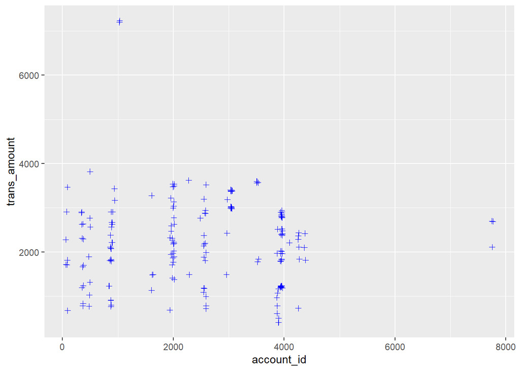

```r
card_withdrawal <- outgoes %>%
  filter(
    trans_operation == "CREDIT CARD WITHDRAWAL"
  )

card_withdrawal %>%
  filter(
    trans_year == 1995,
    period == "1. QUARTER"
    ) %>%
  ggplot(aes(
    x = account_id,
    y = trans_amount
  )) +
  geom_jitter(
    alpha = 1,
    width = 20,
    shape = 3,
    color = "blue"
  )
```

In Tabellenform:

```r
card_withdrawal %>%
  select(
    trans_amount,
    trans_date,
    account_id
  ) %>%
  arrange(
    desc(trans_amount)
  ) %>%
  head
```

```
##   trans_amount trans_date account_id
## 1         8000 1998-02-01         33
## 2         8000 1998-03-29        904
## 3         8000 1998-04-03       2600
## 4         8000 1997-09-14       2867
## 5         8000 1997-02-22       3654
## 6         8000 1997-05-23       3654
```

Die meisten Kreditkartenbezüge sind unter 4000 ? Welche Währung??? Tschechische Krone?

```r
card_withdrawal %>%
  filter(
    trans_amount == 8000
  ) %>%
  count()
```

```
##   n
## 1 7
```

7 mal wurde 8000 Krone mit der Kreditkarte bezogen

```r
card_withdrawal %>%
  filter(
    trans_amount == 8000
  ) %>%
  count(account_id)
```

```
##   account_id n
## 1         33 1
## 2        904 1
## 3       2600 1
## 4       2867 1
## 5       3654 3
```

Account Nr. 3654 fällt durch die drei hohen Kreditkartenbezüge auf.

Account 3654 genauer untersuchen: wann wurden die kreditbezüge getätigt, was ist sonst noch auffällig an diesem account? welche client sind damit verbunden? kann eine Aussage bezüglich Art der Client und umfeld gemacht werden?

#### ii. Zu welchem Zeitpunkt wird am meisten Geld überwiesen? (LBZ)

#### iii. Welche Datenattribute beschreiben den Kundenstamm und wie können Kundengruppen definiert werden? (LBZ)

#### iv. Wann hat die Bank neue Kunden gewonnen und wie sieht diese Verteilung über die Zeit aus? (Christian)

#### iv. Wie sieht die Altersverteilung dieser Kunden aus und was kann daraus hergeleitet werden? (Christian)

#### v. Wieviel Zins wurden durch Kredite erzeugt und wie sieht die Entwicklung über offene Kredite sowie dem erhaltenen Zins aus? (Aaron)

#### vi. Wie sieht die Verteilung von Kreditkartentypen auf die Population der Kreditkarten aus? (Aaron)

#### vii. Wie sieht die Verteilung der Typen von Dispositionen aus? (Aaron)

#### viii. Was ist der am beliebtesten Modus einer Transaktion? (Aaron)

#### ix. Aus welchen Gründen (Charakterisierung) werden Transaktion durchgeführt und wie sieht die Verteilung dieser aus? (Aaron)

#### x. In welchen Distrikten gibt es den höchsten Lohn? (Aaron)

#### xi. Können neue Sonderangebote/Pakete geschaffen werden für die am meist verdienenden Kunden? (Aaron)

### b. Für Korrelationen zwischen Datenattributen:

#### i. Prognosen für die Bank erarbeiten, um festzustellen, ob Kunden ihre Kredite zurückzahlen können. Die Kreditwürdigkeit des Kunden kann mithilfe der Analyse festgestellt werden und bei bereits laufenden Krediten können Massnahmen getroffen werden.

#### ii. Wie sieht das Verhältnis der Benutzung von verschiedenen Zahlungsmitteln aller getätigten Transaktionen aus? Wie sieht die Entwicklung auf die Zeit aus? Kann man Prognosen daraus herleiten? Müssen wir das Geschäftsmodell anpassen?

#### iii. Wie viele der Kunden verwenden eine Kreditkarte von den Bonusprogrammen? Welche Attribute weisen diese Kunden auf? Können Angebote für spezifische Kundengruppen erstellt werden?

#### iv. Korrelationsanalyse zwischen den Bankdaten und den soziodemografischen Daten.

### 1. Gibt es Unterschiede bei den Cashflows der Distrikte? Wieso gibt es diese Unterschiede? Was unterscheidet diese Distrikte?

### 2. Wie sieht die Distribution von Kunden in den Distrikten aus im Bezug zu den restlichen Einwohnern? Können durch diese Zahlen neue Werbe-Kampagnen gestartet werden, welche zu einem Zuwachs von Kunden führen?

### 3. Wie sieht die Entwicklung des Einkommens im Bezug zu den Prüfvariablen der Arbeitslosenrate und den begangenen Straftaten.

#### v. Kann man Unterschiede herleiten, um Geschäfts- und Privatkunden zu unterteilen?

#### vi. Wie sieht die Entwicklung der Kredite in Bezug auf Typ und Dauer aus? Kann aus der Grafik ein Trend ausgelesen werden?

### 3. Welches Potenzial haben jegliche Datenobjekte und mit Hilfe welcher Mittel kann das beste Produkt daraus generiert werden? (Aaron) und jeder der noch kann….